# Coursera Machine Leaning Assignment

Aron O’Connor

December 29, 2016

## Introduction

This report analyzes data from accelerometers on the belt, forearm, arm, and dumbell of 6 participants in order to predict (using machine learning techniques) whether a dumbell bicep curl is being performed correctly or not. The data used in this analysis was downloaded from a website containing human activity recognition exercises and is cited in the appendix. Several key packages were used in this analysis and are listed below for reproduceability purposes, and testing/training partitions are created prior to performing any analysis or exploration.

library(caret) library(ggplot2) library(grid) library(gridExtra) library(randomForest)

```r
df <- read.csv("pml-training.csv")
inTrain <- createDataPartition(y=df$classe, p=0.7, list=F)
train <- df[inTrain,]
test <- df[-inTrain,]
train$classe <- as.factor(train$classe)
```

## Data Analysis

Before attempting any machine learning techniques, let’s see if we can infer any basic patterns in the data by doing some plotting. There are a TON of variables in this data set (160), but a few that may be useful to take a look at. We will start by plotting the total acceleration for eache sensor with respect to classe.

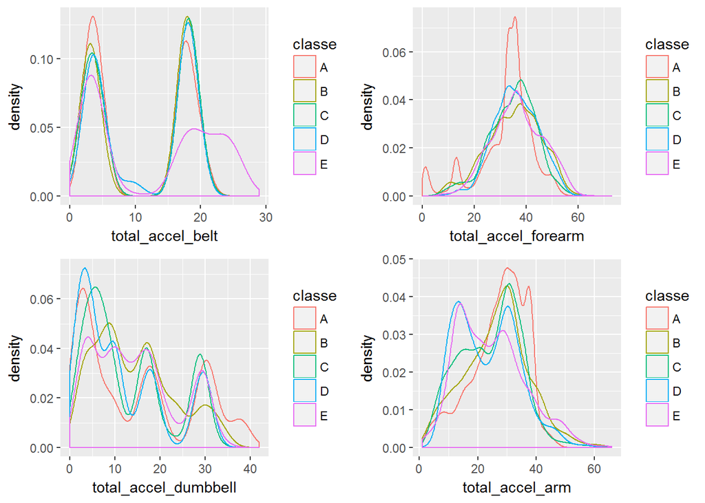

```r
q1 <- qplot(total_accel_belt, colour=classe, data=train, geom="density")
q2 <- qplot(total_accel_forearm, colour=classe, data=train, geom="density")
q3 <- qplot(total_accel_dumbbell, colour=classe, data=train, geom="density")
q4 <- qplot(total_accel_arm, colour=classe, data=train, geom="density")
grid.arrange(q1,q2,q3,q4, ncol=2)
```

```r
train_cmplt <- train[,c(8:11,36:48,59:67,83:85,101,112:123,139,150:160)]
train_cmplt[is.na(train_cmplt)] <- 0
modfit <- train(classe ~ ., data=train_cmplt, method="gbm", verbose=F)
print(modfit)
```

```
## Stochastic Gradient Boosting
##
## 13737 samples
##    53 predictor
##     5 classes: 'A', 'B', 'C', 'D', 'E'
##
## No pre-processing
## Resampling: Bootstrapped (25 reps)
## Summary of sample sizes: 13737, 13737, 13737, 13737, 13737, 13737, ...
## Resampling results across tuning parameters:
##
##   interaction.depth  n.trees  Accuracy   Kappa
##   1                   50      0.7452770  0.6770953
##   1                  100      0.8138500  0.7644195
##   1                  150      0.8476635  0.8072521
##   2                   50      0.8523821  0.8130771
##   2                  100      0.9024386  0.8765755
##   2                  150      0.9258222  0.9061563
##   3                   50      0.8937819  0.8655770
##   3                  100      0.9358792  0.9188790
##   3                  150      0.9542359  0.9421007
##
## Tuning parameter 'shrinkage' was held constant at a value of 0.1
##
## Tuning parameter 'n.minobsinnode' was held constant at a value of 10
## Accuracy was used to select the optimal model using  the largest value.
## The final values used for the model were n.trees = 150,
##  interaction.depth = 3, shrinkage = 0.1 and n.minobsinnode = 10.
```

We have a model! Now we can test this model against our test set that was partitioned at the beginning. This is called cross validation. By putting the predicted values in a table with actual classe values from the test set we can get a feel for how accurate the model is.

```r
test_cmplt <- test[,c(8:11,36:48,59:67,83:85,101,112:123,139,150:160)]
test_cmplt[is.na(test_cmplt)] <- 0
pred <- predict(modfit,test_cmplt)
test_cmplt$predRight <- pred==test_cmplt$classe
answers <- table(pred,test_cmplt$classe)
accuracy <- (answers[1,1]+answers[2,2]+answers[3,3]+answers[4,4]+answers[5,5])/sum(answers)
accuracy
```

```
## [1] 0.9636364
```

## Appendix

### Citations

The data set used in this report was aquired from the following source:

Velloso, E.; Bulling, A.; Gellersen, H.; Ugulino, W.; Fuks, H. Qualitative Activity Recognition of Weight Lifting Exercises. Proceedings of 4th International Conference in Cooperation with SIGCHI (Augmented Human ’13) . Stuttgart, Germany: ACM SIGCHI, 2013.

Read more: http://groupware.les.inf.puc-rio.br/har#weight_lifting_exercises#ixzz4UHWjOYgE